# Mapping STI activities across international organisations: Insights from the new portal

Authors: Daniela Valenzuela and Jovana Poznan

The OECD has launched a new beta STIP Compass Portal that maps the Science, Technology and Innovation activities of international organisations. This marks the first time that STIP Compass extends its data collection beyond national policies to include activities of international organisations. The portal aims to serve as a centralised repository of STI activities across organisations, helping to improve transparency, reduce duplication, and support mutual learning and alignment.

This Data Story covers: (1) the motivation behind the portal; (2) the data model developed in collaboration with participating IOs; (3) what the analysis of the collected data reveals and the value of the portal for IO officials, government policy analysts and researchers; and (4) next steps for enriching the evidence base.

## 1. Why a portal on STI activities from international organisations?

It has been estimated that over 250 IOs are involved in STI-related initiatives, ranging from technical assistance and capacity building to policy development and regulatory frameworks (UNESCO, nd). A study of the OECD involving 50 IOs estimated that these have produced over 70,000 international instruments, such as agreements, guidelines, and standards (OECD, 2016). However, significant challenges hinder the effectiveness of this ecosystem; this issue goes beyond the realm of STI.

The main challenges include:

- **Lack of harmonisation:** There is no universally accepted typology of IO international instruments to date, resulting in inconsistent terminology and categorisation across organisations (OECD, 2021). This complicates cross-organisational collaboration and data integration.
- **Data fragmentation:** While IOs collect extensive information on their activities, this data often resides in isolated silos, making it difficult to identify synergies, and gaps.
- **Increased complexity:** Countries interact with an average of 50 IOs, but there is little coordination among these organisations in their approaches to policy (OECD, 2021). This leads to duplicative efforts and inefficiencies.

In this context, the Portal on STI activities of international organisations aims to act as a unifying platform, addressing these challenges by enabling IOs to systematically map and share their activities. Even though over 250 IOs exist, a smaller sample of 12 IOs have been selected for this beta platform.

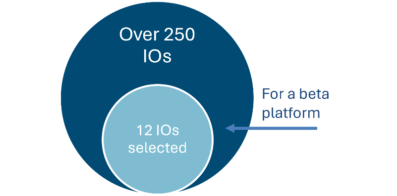

Open larger

## 2. What information does the portal collect?

### 2.1. Unit of Analysis

Different from the STIP Compass general website that collects information on STI policy initiatives from national governments, the new IOs’ STI Portal collects ‘activities’ as the unit of analysis. It should be noted that not all activities implemented by IOs are included in this portal; rather, only major programmes demonstrating continuity are captured.

### Definition of an STI Activity

An IO’s STI activity refers to any initiative, programme, policy, or project undertaken by an international organisation that supports or promotes Science, Technology, and Innovation (STI). These activities can vary widely depending on the organisation’s mandate, sector, and geographic scope.

Activities may involve multiple support mechanisms and multiple direct beneficiaries. Minor administrative actions and isolated events are excluded.

### 2.2. Data model or taxonomy

The data model was developed through an iterative process combining desk research, adaptation to the IOs context, and consultation with participating organisations.

The desk research started from the OECD STIP Compass taxonomy, which provides a structured approach for classifying science, technology and innovation policy initiatives from national governments. This taxonomy was reviewed and adapted to reflect the specific nature of international organisations’ activities, which often differ from national policy initiatives in their mandates, audiences, delivery mechanisms and levels of intervention. The review also considered relevant previous mapping exercises, including the IATT-STI Mapping Sub-Group’s 2017 exercise, which collected around 1,600 UN activities related to STI from 20 UN agencies, as well as GOSPIN from UNESCO which contains relevant classifications of IOs. This helped identify additional elements needed to capture the breadth and heterogeneity of STI-related work across the international system.

Consultations were then carried out with multiple international organisations during 2025 through workshops, one-to-one interviews and written feedback. These consultations tested whether the proposed categories were understandable, usable in a questionnaire format and sufficiently flexible to describe different types of STI-related initiatives.

This process produced a proposed data model and taxonomy for classifying IO initiatives. The model comprises a structured set of fields and response options designed to capture key information on each initiative, combining categorical classifications with open-text fields. It aims to provide sufficient detail for analysis while remaining practical and manageable for organisations to complete.

The result is a beta data model adapted from existing OECD work and refined through IO input. It is intended to support the systematic mapping and analysis of STI-related initiatives across international organisations. As the model is being tested through this project, future versions may be revised based on implementation experience and further feedback

The final proposal is available in the document: IOs initiatives taxonomy proposal - final version.pdf.

Understanding the data model:

Three taxonomic dimensions structure the data model, each characterising a different aspect of an activity:

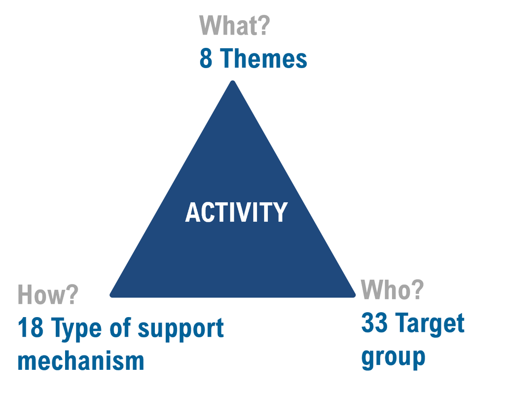

Open larger

1. **Activity themes:** This dimension captures what IOs do to support STI systems. Organisations are asked to report their activities across eight functional roles: Policy Advice, Standard Setting, Monitoring and Data, International Collaboration, Capacity Building, Awareness and Advocacy, Ethics and Responsible Innovation, and Funding.
2. **Support mechanisms:** This dimension captures how IOs support STI systems. Organisations are asked to report the mechanisms through which they deliver their activities and interventions. The data model includes 18 support mechanisms organised into five categories: Governance; Direct Financial Support; Collaborative Infrastructures; Guidance, Regulation and Standardisation; and Capacity Building, Support and Incentives.
3. **Direct beneficiaries:** This dimension captures who benefits from IOs' support to STI systems. Organisations are asked to identify the actors that directly benefit from their activities and interventions. The data model comprises 31 beneficiary types organised into nine categories spanning government entities, research and education organisations, firms, and groups in civic society.

Additional fields capture the level of engagement, alignment with the SDGs, position along the R&D and innovation stages, types of linkages supported in the STI system, partner and donor organisations, budget range, and evaluation status. Open-text fields capture essential contextual information, including the initiative’s description, objectives, background and institutional mandate, and expected impact.

## 3. Main insights from the Data Collected

Data was collected through a structured survey distributed directly to participating IOs between late 2025 and mid-2026. In total, 199 initiatives were reported across 12 organisations. The number of initiatives submitted varied considerably, ranging from 4 to 29 per organisation.

As this was a pilot exercise, such variation largely reflects the limited scope of the initial data collection effort rather than differences in overall levels of STI-related activity. Future iterations are expected to expand the coverage of initiatives and support a more comprehensive mapping across participating organisations.

### Key findings at a glance

The portfolio of activities spans decades, but it is dominated by more recently launched activities. Almost a quarter of activities started before 2001, reflecting programmes that have been running for over two decades. Yet the largest single group, nearly one in three, launched between 2021 and 2025.

The 199 STI activities mapped across 12 international organisations reveal a landscape shaped primarily by knowledge production, convening and norm-setting rather than direct financial support. Policy advice is the most common functional role, followed by international collaboration and capacity building. The most frequently used instruments are policy intelligence including studies, reviews and forecasts, followed closely by capacity building and technical assistance and networking and collaborative platforms. Stakeholder consultation and expert forums and information services and access to datasets are also prominent. Together, these five instruments account for the large majority of how IOs deliver their STI work, pointing to a model centred on evidence generation, knowledge sharing and building the capacity of partners. Two gaps stand out: funding features in fewer than one in twenty activities as a theme, and direct financial support appears in fewer than one in ten as a delivery mechanism, suggesting that the financial dimension of STI support remains largely outside the scope of what IOs report through this portal or outside the scope of what they do.

Activities are predominantly international in reach and oriented towards system-level connections, though engagement with the private sector and market-oriented linkages remains limited. Nine in ten activities with a level of engagement recorded operate at the international level, though close to two in three also have a national dimension. Among activities with linkage data, five in six support linkages across sectors or policy domains, and two in three support linkages between science and society. National governments are the most frequent direct beneficiary, cited in more than four out of five activities, and knowledge institutions including public research institutes, higher education institutes and established researchers feature in more than half, indicating that IOs engage the scientific community directly and not solely through government intermediaries. Private sector actors and market-oriented linkages are considerably less prominent: linkages between firms and between entrepreneurs and investors together account for fewer than one in five activities with linkage data, and private research and development labs appear as a target group in around one in three. These patterns may reflect the intergovernmental nature of participating organisations, but they also point to a potential gap in IO engagement with the innovation actors closest to the market.

The substantive focus of IO activities reflects strong mandate-driven specialisation, with most organisations concentrating in one or two thematic areas closely aligned with their institutional remit. IEA and UNEP focus almost exclusively on green and environmental transitions, WIPO on intellectual property and knowledge assets, WHO on health, ethics and responsible technologies, and NEA on nuclear science, safety and skills. Innovation systems, SDGs and partnerships emerges as the most cross-cutting area, appearing across nearly all organisations. Digital, data and skills transformation is notably concentrated in OECD and OEI, with limited engagement elsewhere.

### 3.3. Trends in activity initiation over time

The activity portfolio is dominated by recently launched and long-standing activities, with a notable dip in between. Almost a third of all activities started between 2021 and 2025, making this the largest single period by far. At the same time, nearly a quarter pre-date 2001, suggesting a core of institutionalised, long-running programmes that have persisted across decades. The periods in between, particularly 2001 to 2015, are comparatively thin, accounting for just close to a quarter % of all the initiatives combined.

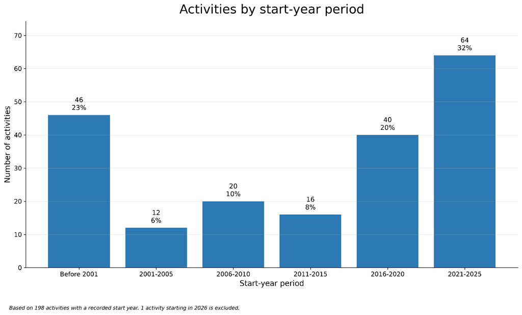

Open larger

### 3.2. The role of international organisations

Across the 199 activities mapped, Policy Advice is the most prevalent theme (33%; 66 activities), followed by Capacity Building (25%; 50 activities), International Collaboration (25%; 49 activities), and Monitoring and Data (25%; 49 activities). Awareness and Advocacy (44 activities) and Standard Setting (43 activities) each account for 22%, while Ethics and Responsible Innovation account for 12% (23). By contrast, Funding is relatively uncommon, appearing in only 5% of activities (9), suggesting that most organisations contribute to STI systems through co-ordination, knowledge provision and standards rather than direct financial support.

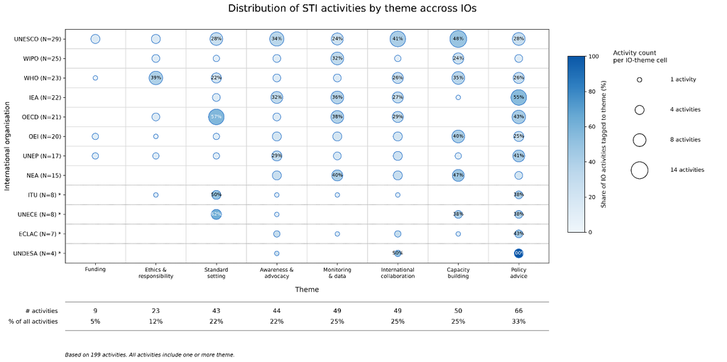

Open larger

### 3.3. How do IOs deliver their activities?

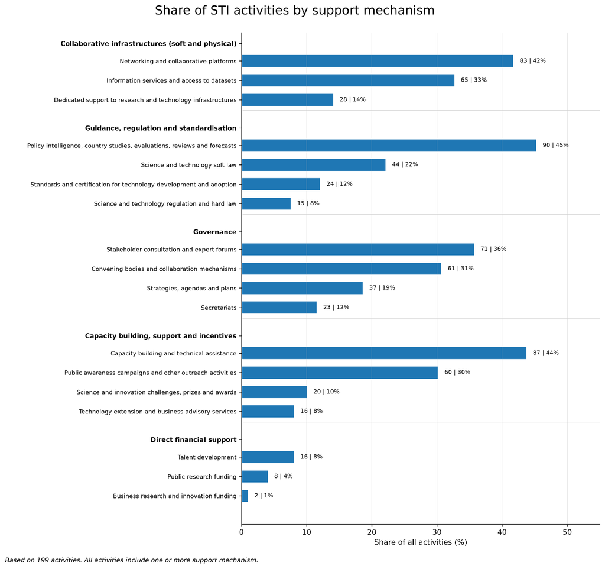

Open larger

### 3.4. What are the main target groups of IOs activities?

National governments are the most frequent direct beneficiary, appearing in 84% of activities (167), followed by international organisations in 60% (120), reflecting the collaborative and network-building character of much IO work. Public research institutes appear in 56% of activities (112), established researchers in 57% (113) and higher education institutes in 55% (110), while academic societies and academies feature in 48% (95) and PhD students, postdocs and other early-career researchers in 46% (92). Regional government appears in 37% of activities (74). Private research and development labs appear in 34% of activities (67) and non-governmental organisations and foundations in 34% (68), while firms of any age (22%; 44), SMEs and micro-enterprises (23%; 46) and private investors (18%; 36) are considerably less represented. Taken together, the target group distribution points to a model of engagement centred on national governments and the research community, with comparatively limited direct reach to firms, investors and civil society organisations.

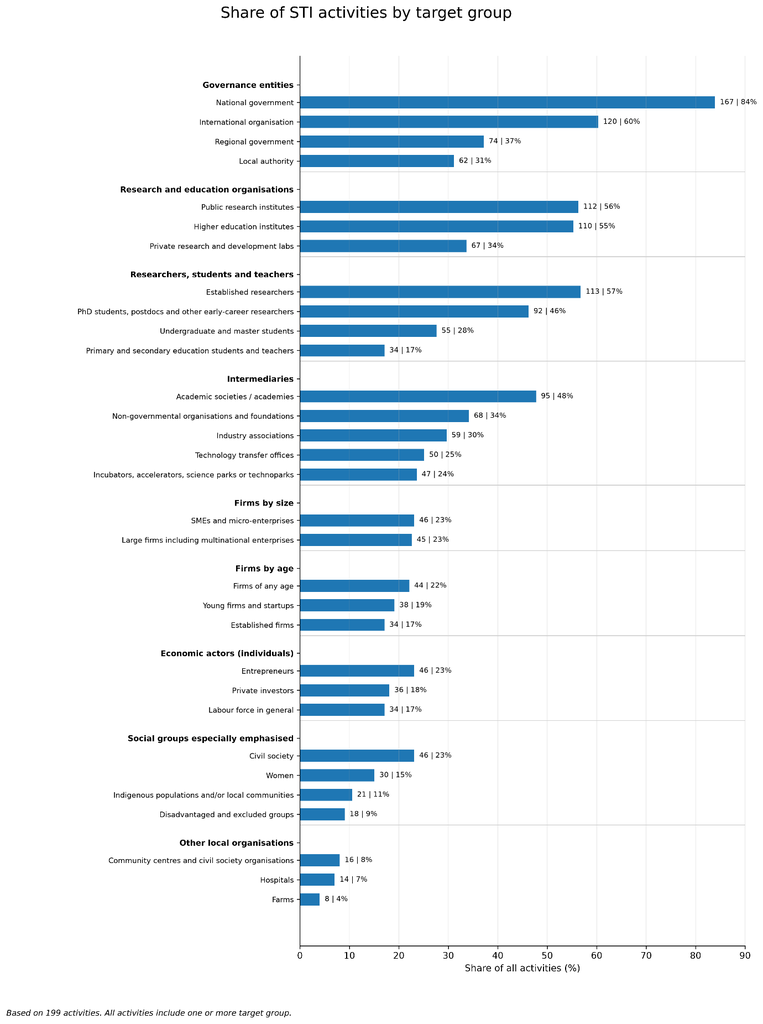

Open larger

### 3.5. What is the level of engagement in these activities?

Activities are concentrated at the international level, which features in 94% of activities with a level recorded (152 activities). The national level is also a significant focus, appearing in 61% of activities with a level recorded (99 activities), suggesting that many initiatives are designed to support implementation, capacity building or policy development within countries. In contrast, only 12% of activities with a level recorded involve the local level (20 activities). Overall, the results indicate that IO activities are primarily oriented towards international co-operation and co-ordination, while maintaining substantial engagement with national STI systems

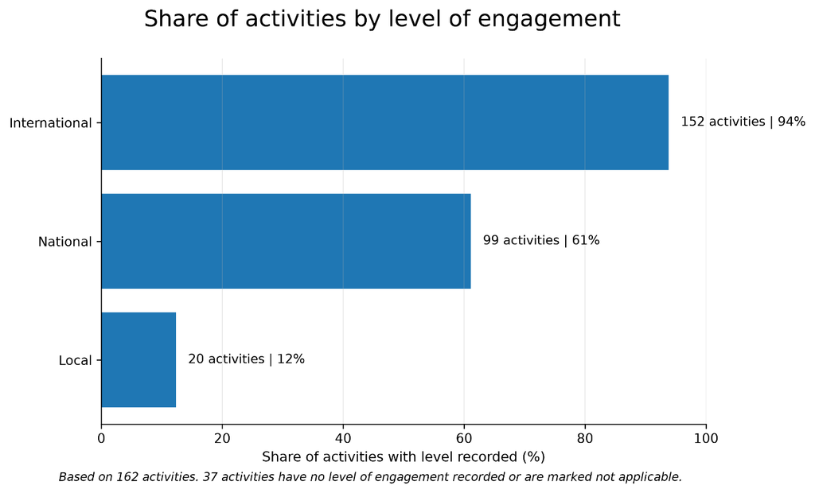

Open larger

### 3.6. What linkages do IOs support in the STI system?

The results suggest that international organisations primarily support system-level linkages within STI systems rather than narrowly targeted commercial relationships. The most common linkage type is across sectors or policy domains, appearing in 85% of valid responses (129 activities), followed by science and society (65%; 99 activities) and research organisations and research fields (51%; 78 activities). Linkages between public research and industry (44%; 67 activities) and across whole innovation ecosystems (48%; 73 activities) are also well represented. By contrast, linkages focused on firms (18%; 27 activities) and entrepreneurs and investors (14%; 22 activities) are considerably less common. This pattern indicates that IOs mainly contribute by connecting actors, institutions and policy domains, facilitating co-ordination and knowledge flows across the broader innovation system. Their activities are therefore oriented more towards strengthening innovation ecosystems and addressing systemic challenges than towards supporting individual market transactions or firm-level relationships.

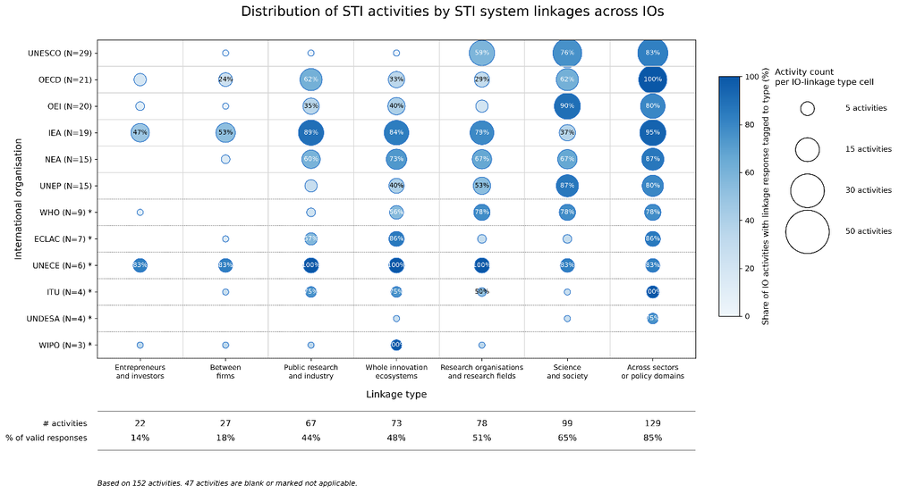

Open larger

### 3.7. How is IO activity distributed across the R&D and innovation chain?

The distribution of activities across the R&D and innovation chain shows that international organisations support all stages of the innovation process, with a particularly strong emphasis on applied research (77% of valid responses; 89 activities). This is followed by diffusion (61%; 70 activities), experimental development (60%; 69 activities), deployment (59%; 68 activities) and demonstration (50%; 58 activities), while basic research (44%; 51 activities) is somewhat less prominent. The relatively balanced distribution across stages suggests that international organisations are not focused solely on knowledge generation, but also play an important role in helping technologies and practices move towards deployment and wider adoption. Overall, the results point to a broad systems-oriented approach that spans the full innovation cycle, from knowledge creation to the diffusion of innovations and technologies.

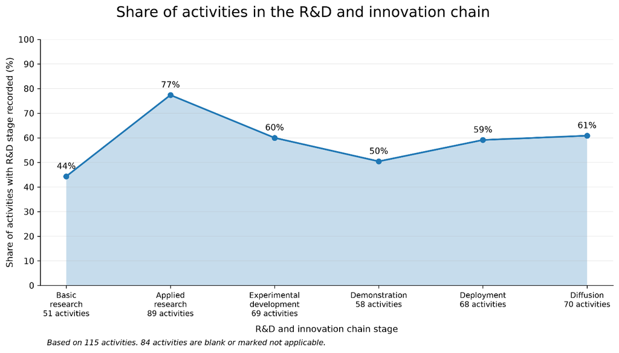

Open larger

Organisational profiles diverge most clearly at the extremes of the innovation stages. Organisations such as IEA and OECD show strong engagement across experimental development, demonstration and deployment, consistent with their focus on technology transition and policy implementation. UNESCO, by contrast, concentrates at applied research and diffusion while showing limited presence in the intermediate translation stages, reflecting a profile centred on knowledge generation and dissemination rather than deployment support.

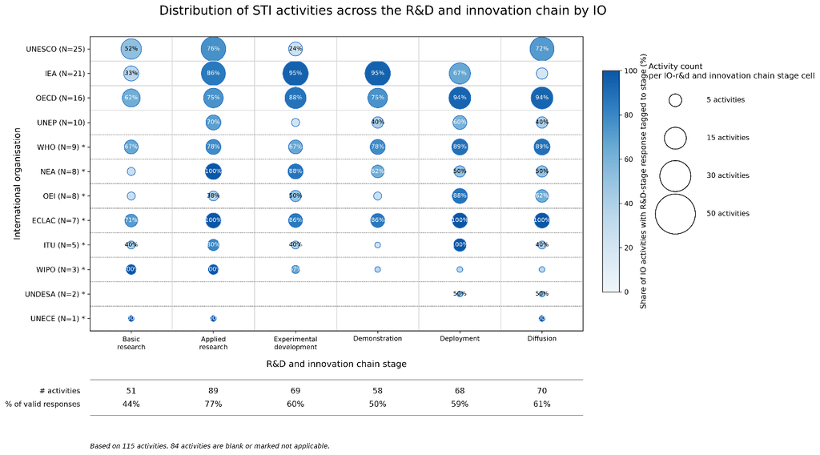

Open larger

## 4. Looking ahead: further enriching the evidence base

Looking ahead, the Portal is expected to expand both in terms of participating organisations and its data coverage. The survey underpinning the data collection is envisaged to be conducted on a biennial basis, enabling regular updates with new evidence and insights. Several international organisations have already engaged in the initial phases of the project - through consultations, and shaping of the data model - and represent a strong foundation for broadening participation in future iterations.

The Portal marks an important step towards rendering the collective STI engagement of IOs more visible, comparable and actionable. As the evidence base grows, it has the potential to support more informed co-ordination and strategic alignment across the international landscape. It can serve as a practical resource for officials within international organisations seeking synergies and partnerships, for government stakeholders aiming to better navigate and leverage international support, and for researchers and analysts examining the evolving architecture of global STI governance.

## References

- OECD (2016), International Regulatory Co-operation: The Role of International Organisations in Fostering Better Rules of Globalisation, https://doi.org/10.1787/9789264244047-en
- OECD (2021), Compendium of International Organisations’ Practices: Working Towards More Effective International Instruments, https://doi.org/10.1787/846a5fa0-en
- IATT-STI’s Mapping Sub-Group (2017), Landscape of Science, Technology and Innovation initiatives for the SDGs, https://sustainabledevelopment.un.org/content/documents/17447IATTLandscape_of_STIInitiatives_for_SDGs.pdf
- UNESCO GOSPIN https://gospin.unesco.org/

Close

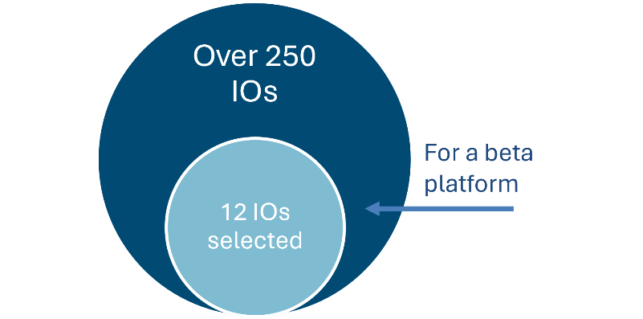

Close

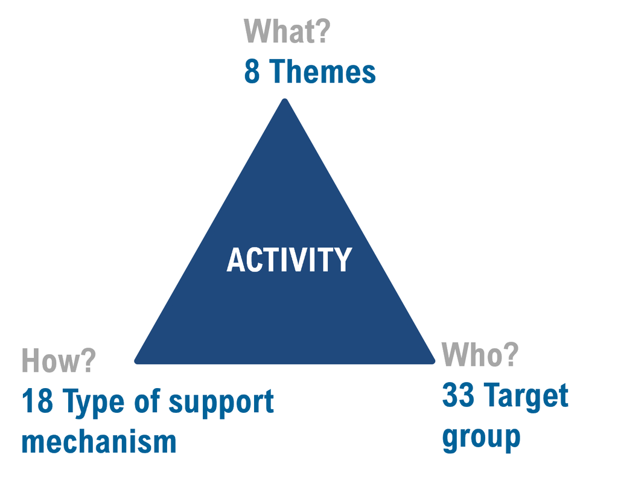

Close

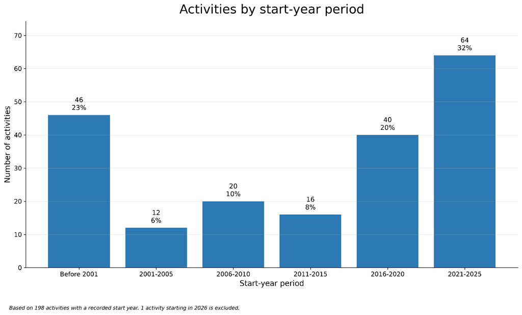

Close

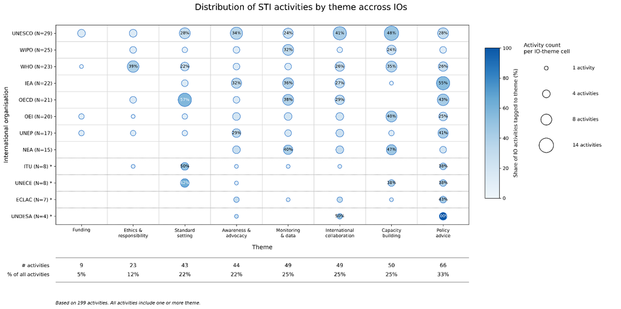

Close

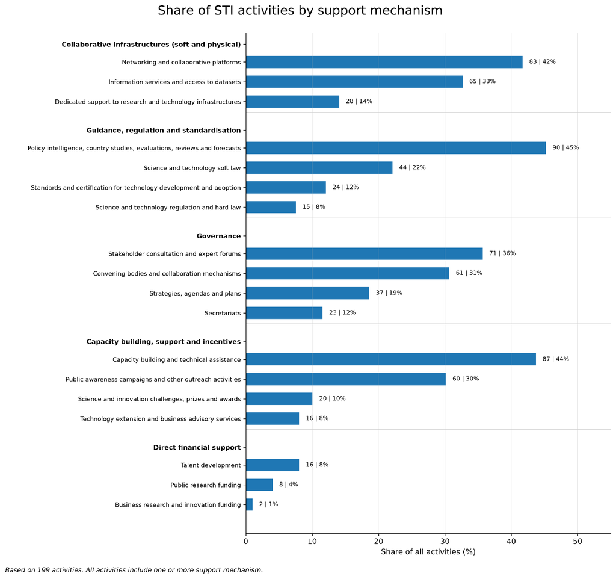

Close

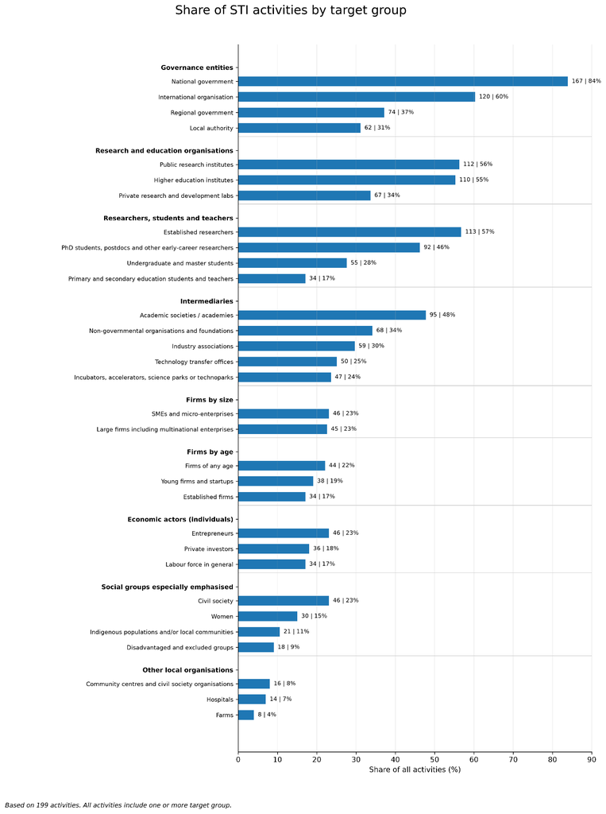

Close

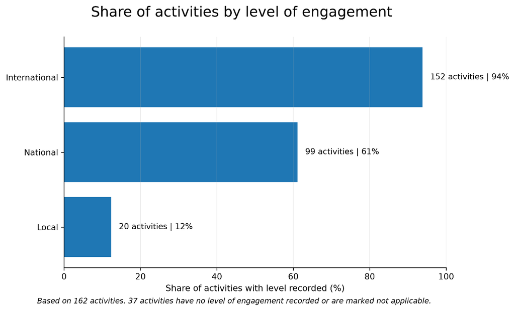

Close

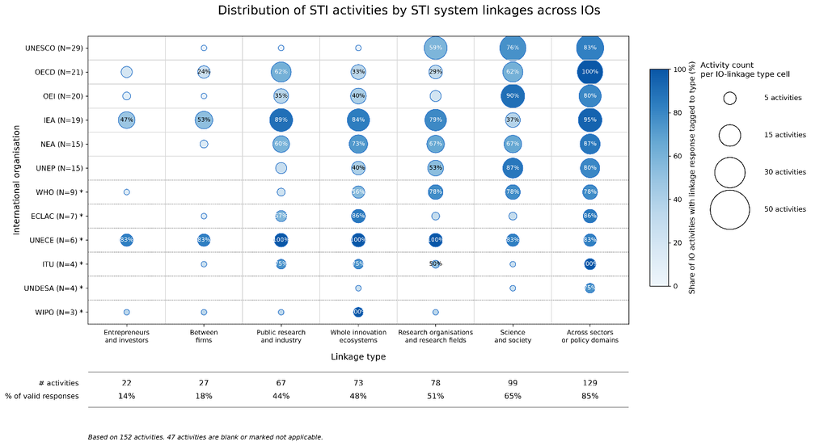

Close

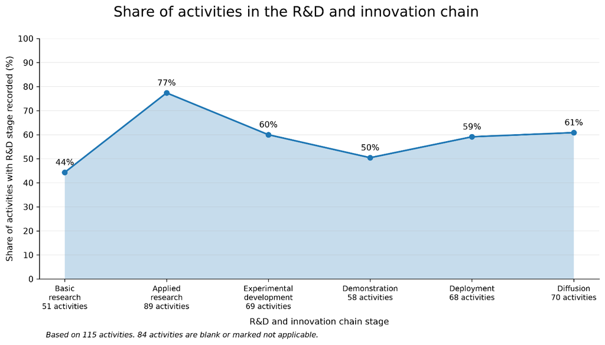

Close

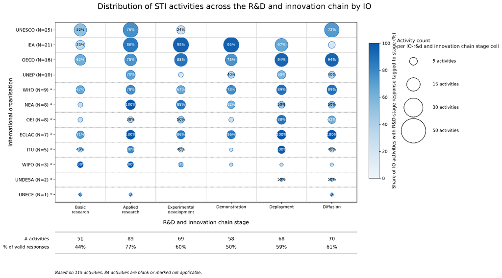